# Project: Investigating the TMDB MOVIES Dataset

Table of contents

- Introduction
- Data Wrangling
- Exploratory Data Analysis
- Conclusions

# Introduction

**Dataset**

This project analyzes the TMDB MOVIES dataset. The dataset contains information about 10,866 movies collected from The Movie Database (TMDb), including user average ratings, bugdet and revenue. This analysis intends to find interesting trends in the dataset.

The tmdb dataset contains 21 attributes of 10,866 movies released from the year 1960 to 2015. These attributes include the

1. id
2. imdb_id
3. popularity
4. budget
5. revenue
6. original_title
7. cast
8. homepage
9. director
10. tagline
11. keywords
12. overview
13. runtime
14. genres
15. production_companies
16. release_date
17. vote_count
18. vote_average
19. release_year
20. budget_adj
21. revenue_adj

**Questions which this analysis will cover are**

```python
# importing libraries

import pandas as pd
import numpy as np
import matplotlib.pyplot as plt
import seaborn as sns

sns.set_style('darkgrid')
%matplotlib inline
```

# Data Wrangling

```python
tmdb_data = pd.read_csv('C:/Users/USER/Desktop/Udacity/Udacity Project/tmdb-movies.csv')
tmdb_data.head()
```

|  | id | imdb_id | popularity | budget | revenue | original_title | cast | homepage | director | tagline | ... | overview | runtime | genres | production_companies | release_date | vote_count | vote_average | release_year | budget_adj | revenue_adj |
| --- | --- | --- | --- | --- | --- | --- | --- | --- | --- | --- | --- | --- | --- | --- | --- | --- | --- | --- | --- | --- | --- |
| 0 | 135397 | tt0369610 | 32.985763 | 150000000 | 1513528810 | Jurassic World | Chris Pratt\|Bryce Dallas Howard\|Irrfan Khan\|Vi... | http://www.jurassicworld.com/ | Colin Trevorrow | The park is open. | ... | Twenty-two years after the events of Jurassic ... | 124 | Action\|Adventure\|Science Fiction\|Thriller | Universal Studios\|Amblin Entertainment\|Legenda... | 6/9/15 | 5562 | 6.5 | 2015 | 1.379999e+08 | 1.392446e+09 |
| 1 | 76341 | tt1392190 | 28.419936 | 150000000 | 378436354 | Mad Max: Fury Road | Tom Hardy\|Charlize Theron\|Hugh Keays-Byrne\|Nic... | http://www.madmaxmovie.com/ | George Miller | What a Lovely Day. | ... | An apocalyptic story set in the furthest reach... | 120 | Action\|Adventure\|Science Fiction\|Thriller | Village Roadshow Pictures\|Kennedy Miller Produ... | 5/13/15 | 6185 | 7.1 | 2015 | 1.379999e+08 | 3.481613e+08 |
| 2 | 262500 | tt2908446 | 13.112507 | 110000000 | 295238201 | Insurgent | Shailene Woodley\|Theo James\|Kate Winslet\|Ansel... | http://www.thedivergentseries.movie/#insurgent | Robert Schwentke | One Choice Can Destroy You | ... | Beatrice Prior must confront her inner demons ... | 119 | Adventure\|Science Fiction\|Thriller | Summit Entertainment\|Mandeville Films\|Red Wago... | 3/18/15 | 2480 | 6.3 | 2015 | 1.012000e+08 | 2.716190e+08 |
| 3 | 140607 | tt2488496 | 11.173104 | 200000000 | 2068178225 | Star Wars: The Force Awakens | Harrison Ford\|Mark Hamill\|Carrie Fisher\|Adam D... | http://www.starwars.com/films/star-wars-episod... | J.J. Abrams | Every generation has a story. | ... | Thirty years after defeating the Galactic Empi... | 136 | Action\|Adventure\|Science Fiction\|Fantasy | Lucasfilm\|Truenorth Productions\|Bad Robot | 12/15/15 | 5292 | 7.5 | 2015 | 1.839999e+08 | 1.902723e+09 |
| 4 | 168259 | tt2820852 | 9.335014 | 190000000 | 1506249360 | Furious 7 | Vin Diesel\|Paul Walker\|Jason Statham\|Michelle ... | http://www.furious7.com/ | James Wan | Vengeance Hits Home | ... | Deckard Shaw seeks revenge against Dominic Tor... | 137 | Action\|Crime\|Thriller | Universal Pictures\|Original Film\|Media Rights ... | 4/1/15 | 2947 | 7.3 | 2015 | 1.747999e+08 | 1.385749e+09 |

5 rows × 21 columns

```python
tmdb_data.shape
```

```
(10866, 21)
```

```python
tmdb_data.describe()
```

|  | id | popularity | budget | revenue | runtime | vote_count | vote_average | release_year | budget_adj | revenue_adj |
| --- | --- | --- | --- | --- | --- | --- | --- | --- | --- | --- |
| count | 10866.000000 | 10866.000000 | 1.086600e+04 | 1.086600e+04 | 10866.000000 | 10866.000000 | 10866.000000 | 10866.000000 | 1.086600e+04 | 1.086600e+04 |
| mean | 66064.177434 | 0.646441 | 1.462570e+07 | 3.982332e+07 | 102.070863 | 217.389748 | 5.974922 | 2001.322658 | 1.755104e+07 | 5.136436e+07 |
| std | 92130.136561 | 1.000185 | 3.091321e+07 | 1.170035e+08 | 31.381405 | 575.619058 | 0.935142 | 12.812941 | 3.430616e+07 | 1.446325e+08 |
| min | 5.000000 | 0.000065 | 0.000000e+00 | 0.000000e+00 | 0.000000 | 10.000000 | 1.500000 | 1960.000000 | 0.000000e+00 | 0.000000e+00 |
| 25% | 10596.250000 | 0.207583 | 0.000000e+00 | 0.000000e+00 | 90.000000 | 17.000000 | 5.400000 | 1995.000000 | 0.000000e+00 | 0.000000e+00 |
| 50% | 20669.000000 | 0.383856 | 0.000000e+00 | 0.000000e+00 | 99.000000 | 38.000000 | 6.000000 | 2006.000000 | 0.000000e+00 | 0.000000e+00 |
| 75% | 75610.000000 | 0.713817 | 1.500000e+07 | 2.400000e+07 | 111.000000 | 145.750000 | 6.600000 | 2011.000000 | 2.085325e+07 | 3.369710e+07 |
| max | 417859.000000 | 32.985763 | 4.250000e+08 | 2.781506e+09 | 900.000000 | 9767.000000 | 9.200000 | 2015.000000 | 4.250000e+08 | 2.827124e+09 |

```python
tmdb_data.info()
```

```
<class 'pandas.core.frame.DataFrame'>
RangeIndex: 10866 entries, 0 to 10865
Data columns (total 21 columns):
 #   Column                Non-Null Count  Dtype
---  ------                --------------  -----
 0   id                    10866 non-null  int64
 1   imdb_id               10856 non-null  object
 2   popularity            10866 non-null  float64
 3   budget                10866 non-null  int64
 4   revenue               10866 non-null  int64
 5   original_title        10866 non-null  object
 6   cast                  10790 non-null  object
 7   homepage              2936 non-null   object
 8   director              10822 non-null  object
 9   tagline               8042 non-null   object
 10  keywords              9373 non-null   object
 11  overview              10862 non-null  object
 12  runtime               10866 non-null  int64
 13  genres                10843 non-null  object
 14  production_companies  9836 non-null   object
 15  release_date          10866 non-null  object
 16  vote_count            10866 non-null  int64
 17  vote_average          10866 non-null  float64
 18  release_year          10866 non-null  int64
 19  budget_adj            10866 non-null  float64
 20  revenue_adj           10866 non-null  float64
dtypes: float64(4), int64(6), object(11)
memory usage: 1.7+ MB
```

Checking the dataset info helps us to see that there are some missing values in the dataset and that the release_date column is not in its correct format.

```python
# Checking for null values in the dataset

tmdb_data.isna().sum()
```

```
id                         0
imdb_id                   10
popularity                 0
budget                     0
revenue                    0
original_title             0
cast                      76
homepage                7930
director                  44
tagline                 2824
keywords                1493
overview                   4
runtime                    0
genres                    23
production_companies    1030
release_date               0
vote_count                 0
vote_average               0
release_year               0
budget_adj                 0
revenue_adj                0
dtype: int64
```

Checking for the null values helps us to see that the following columns have null values.

1. imdb_id
2. cast
3. homepage
4. director
5. tagline
6. keywords
7. overview
8. genres
9. production_companies

```python
# Checking for the total number of null values in the dataset

tmdb_data.isna().sum().sum()
```

```
13434
```

There are a total of 13434 null values in the dataset

```python
tmdb_data.duplicated().sum()
```

```
1
```

There is only 1 duplicated row in the dataset

The line of code below checks whether there are rows with either the budget or the revenue field equal to 0

```python
# checking for rows with zero value of budget or revenue

tmdb_data.query("budget == 0 | revenue == 0")
```

|  | id | imdb_id | popularity | budget | revenue | original_title | cast | homepage | director | tagline | ... | overview | runtime | genres | production_companies | release_date | vote_count | vote_average | release_year | budget_adj | revenue_adj |
| --- | --- | --- | --- | --- | --- | --- | --- | --- | --- | --- | --- | --- | --- | --- | --- | --- | --- | --- | --- | --- | --- |
| 30 | 280996 | tt3168230 | 3.927333 | 0 | 29355203 | Mr. Holmes | Ian McKellen\|Milo Parker\|Laura Linney\|Hattie M... | http://www.mrholmesfilm.com/ | Bill Condon | The man behind the myth | ... | The story is set in 1947, following a long-ret... | 103 | Mystery\|Drama | BBC Films\|See-Saw Films\|FilmNation Entertainme... | 6/19/15 | 425 | 6.4 | 2015 | 0.000000e+00 | 2.700677e+07 |
| 36 | 339527 | tt1291570 | 3.358321 | 0 | 22354572 | Solace | Abbie Cornish\|Jeffrey Dean Morgan\|Colin Farrel... | NaN | Afonso Poyart | A serial killer who can see your future, a psy... | ... | A psychic doctor, John Clancy, works with an F... | 101 | Crime\|Drama\|Mystery | Eden Rock Media\|FilmNation Entertainment\|Flynn... | 9/3/15 | 474 | 6.2 | 2015 | 0.000000e+00 | 2.056620e+07 |
| 48 | 265208 | tt2231253 | 2.932340 | 30000000 | 0 | Wild Card | Jason Statham\|Michael Angarano\|Milo Ventimigli... | NaN | Simon West | Never bet against a man with a killer hand. | ... | When a Las Vegas bodyguard with lethal skills ... | 92 | Thriller\|Crime\|Drama | Current Entertainment\|Lionsgate\|Sierra / Affin... | 1/14/15 | 481 | 5.3 | 2015 | 2.759999e+07 | 0.000000e+00 |
| 67 | 334074 | tt3247714 | 2.331636 | 20000000 | 0 | Survivor | Pierce Brosnan\|Milla Jovovich\|Dylan McDermott\|... | http://survivormovie.com/ | James McTeigue | His Next Target is Now Hunting Him | ... | A Foreign Service Officer in London tries to p... | 96 | Crime\|Thriller\|Action | Nu Image Films\|Winkler Films\|Millennium Films\|... | 5/21/15 | 280 | 5.4 | 2015 | 1.839999e+07 | 0.000000e+00 |
| 72 | 284289 | tt2911668 | 2.272044 | 0 | 45895 | Beyond the Reach | Michael Douglas\|Jeremy Irvine\|Hanna Mangan Law... | NaN | Jean-Baptiste LÃ©onetti | NaN | ... | A high-rolling corporate shark and his impover... | 95 | Thriller | Furthur Films | 4/17/15 | 81 | 5.5 | 2015 | 0.000000e+00 | 4.222338e+04 |
| ... | ... | ... | ... | ... | ... | ... | ... | ... | ... | ... | ... | ... | ... | ... | ... | ... | ... | ... | ... | ... | ... |
| 10861 | 21 | tt0060371 | 0.080598 | 0 | 0 | The Endless Summer | Michael Hynson\|Robert August\|Lord 'Tally Ho' B... | NaN | Bruce Brown | NaN | ... | The Endless Summer, by Bruce Brown, is one of ... | 95 | Documentary | Bruce Brown Films | 6/15/66 | 11 | 7.4 | 1966 | 0.000000e+00 | 0.000000e+00 |
| 10862 | 20379 | tt0060472 | 0.065543 | 0 | 0 | Grand Prix | James Garner\|Eva Marie Saint\|Yves Montand\|Tosh... | NaN | John Frankenheimer | Cinerama sweeps YOU into a drama of speed and ... | ... | Grand Prix driver Pete Aron is fired by his te... | 176 | Action\|Adventure\|Drama | Cherokee Productions\|Joel Productions\|Douglas ... | 12/21/66 | 20 | 5.7 | 1966 | 0.000000e+00 | 0.000000e+00 |
| 10863 | 39768 | tt0060161 | 0.065141 | 0 | 0 | Beregis Avtomobilya | Innokentiy Smoktunovskiy\|Oleg Efremov\|Georgi Z... | NaN | Eldar Ryazanov | NaN | ... | An insurance agent who moonlights as a carthie... | 94 | Mystery\|Comedy | Mosfilm | 1/1/66 | 11 | 6.5 | 1966 | 0.000000e+00 | 0.000000e+00 |
| 10864 | 21449 | tt0061177 | 0.064317 | 0 | 0 | What's Up, Tiger Lily? | Tatsuya Mihashi\|Akiko Wakabayashi\|Mie Hama\|Joh... | NaN | Woody Allen | WOODY ALLEN STRIKES BACK! | ... | In comic Woody Allen's film debut, he took the... | 80 | Action\|Comedy | Benedict Pictures Corp. | 11/2/66 | 22 | 5.4 | 1966 | 0.000000e+00 | 0.000000e+00 |
| 10865 | 22293 | tt0060666 | 0.035919 | 19000 | 0 | Manos: The Hands of Fate | Harold P. Warren\|Tom Neyman\|John Reynolds\|Dian... | NaN | Harold P. Warren | It's Shocking! It's Beyond Your Imagination! | ... | A family gets lost on the road and stumbles up... | 74 | Horror | Norm-Iris | 11/15/66 | 15 | 1.5 | 1966 | 1.276423e+05 | 0.000000e+00 |

7011 rows × 21 columns

```python
# cheking for unneeded columns for the analysis

tmdb_data.columns
```

```
Index(['id', 'imdb_id', 'popularity', 'budget', 'revenue', 'original_title',
       'cast', 'homepage', 'director', 'tagline', 'keywords', 'overview',
       'runtime', 'genres', 'production_companies', 'release_date',
       'vote_count', 'vote_average', 'release_year', 'budget_adj',
       'revenue_adj'],
      dtype='object')
```

# Data Cleaning

Under data cleaning, the following things are done.

1. I dropped the duplicate row
2. I changed the format of the release_date column into the datetime format
3. I removed all the unneeded columns that are not needed in the analysis
4. I removed the movies which are having zero value of budget or revenue
5. I replaced all the null values with "Unknown"

First of all I drop the duplicate rows with the line of code below

```python
# dropping the duplicate values in the dataset

tmdb_data.drop_duplicates(inplace=True)
```

Then I convert the release_date column into the datetime format

```python
# converting the release_date column to datetime format

tmdb_data['release_date'] = pd.to_datetime(tmdb_data['release_date'])
```

I remove the unneeded columns in the line of code below

```python
# dropping all the unneeded columns for the analysis

tmdb_data.drop(['homepage', 'tagline', 'overview', 'budget_adj', 'revenue_adj', 'imdb_id', 'vote_count'], axis=1, inplace=True)
```

As we have seen earlier, the dataset contains rows which have either the budget or the revenue equal to zero. I will assume that those movies were not released and hence remove them from the dataset in order to obtain correct and accurate analysis.

```python
# first if all getting the indexes of those rows

ind_drop = tmdb_data.query("budget == 0 | revenue == 0").index
```

```python
# dropping all the rows

tmdb_data.drop(ind_drop, inplace=True)
```

Lastly I fill all null values with the value "Unknown"

```python
# replacing null values with "Unknown"

tmdb_data.fillna('Unknown', inplace=True)
```

# Exploratory Data Analysis

# What kind of properties are associated with movies that have high revenue?

```python
tmdb_data.columns
```

```
Index(['id', 'popularity', 'budget', 'revenue', 'original_title', 'cast',
       'director', 'keywords', 'runtime', 'genres', 'production_companies',
       'release_date', 'vote_average', 'release_year'],
      dtype='object')
```

```python
tmdb_data['revenue']
```

```
0        1513528810
1         378436354
2         295238201
3        2068178225
4        1506249360
            ...
10822      33736689
10828      13000000
10829       6000000
10835      20000000
10848      12000000
Name: revenue, Length: 3854, dtype: int64
```

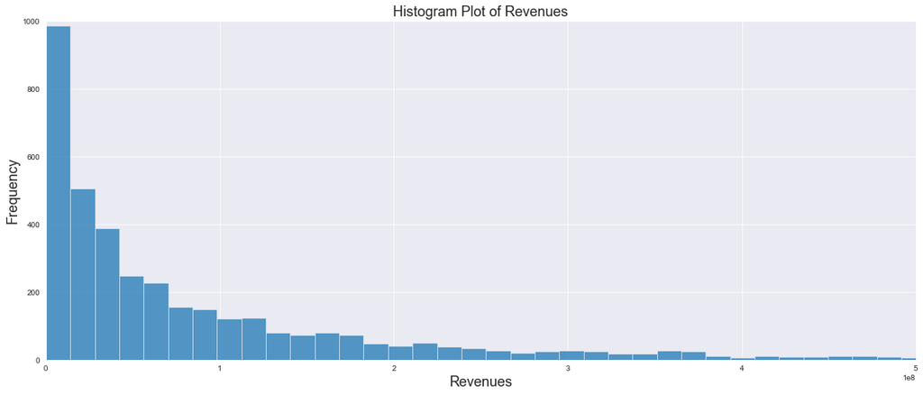

```python
# plotting a histogram of revenues

plt.figure(figsize=(20,8))
plot_ = sns.histplot(data=tmdb_data, x='revenue')
plot_.set_ylim([0,1000])
plot_.set_xlim([-1e5,0.5e9])
plt.xlabel('Revenues', fontdict={'fontsize': 18})
plt.ylabel('Frequency', fontdict={'fontsize': 18})
plt.title('Histogram Plot of Revenues', fontdict={'fontsize': 18})
plt.show()
```

Most companies generate lesser revenue from the histogram above, the distribution is right-skewed

```python
# brief summary statistics of the revenue column

print(tmdb_data['revenue'].describe())
```

```
count    3.854000e+03
mean     1.076866e+08
std      1.765393e+08
min      2.000000e+00
25%      1.360003e+07
50%      4.480000e+07
75%      1.242125e+08
max      2.781506e+09
Name: revenue, dtype: float64
```

I will assume that values from the 90th percentile and above are the high revenue values

```python
rev_90th = np.quantile(tmdb_data['revenue'], 0.9)
```

```python
tmdb_high_rev = tmdb_data[tmdb_data['revenue'] >= rev_90th]
```

```python
tmdb_high_rev.columns
```

```
Index(['id', 'popularity', 'budget', 'revenue', 'original_title', 'cast',
       'director', 'keywords', 'runtime', 'genres', 'production_companies',
       'release_date', 'vote_average', 'release_year'],
      dtype='object')
```

```python
tmdb_high_rev['director']
```

```
0         Colin Trevorrow
1           George Miller
2        Robert Schwentke
3             J.J. Abrams
4               James Wan
               ...
10226        Andrew Davis
10475          Tony Scott
10499        Peter Faiman
10594    William Friedkin
10758      Richard Donner
Name: director, Length: 386, dtype: object
```

```python
tmdb_high_rev['director'].value_counts().head(5)
```

```
Steven Spielberg    15
Robert Zemeckis      7
Peter Jackson        7
Michael Bay          6
Ron Howard           6
Name: director, dtype: int64
```

```python
# getting the most common comapnies associated with high revenues

most_common_comp_for_high_rev = tmdb_high_rev['production_companies'].value_counts().head(10).sort_values()
```

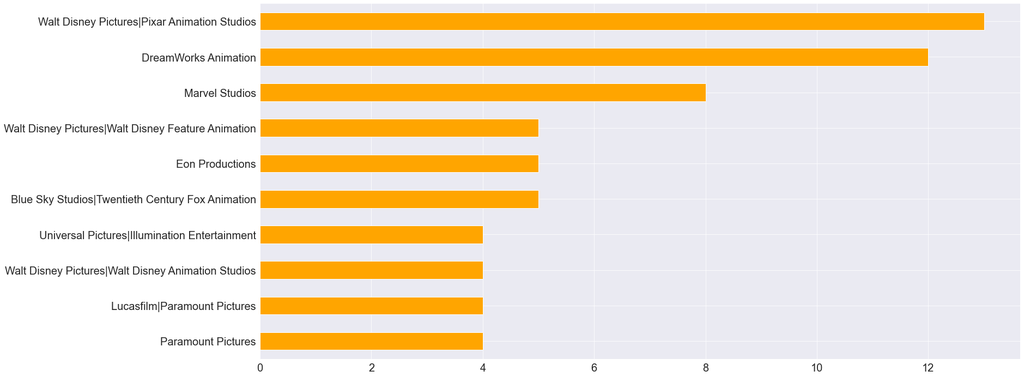

```python
most_common_comp_for_high_rev.plot(kind='barh', figsize=(25,12), color='orange', fontsize=20)
```

From the bar plot above movies produced by these companies tend to have high revenue

1. Walt Disney Pictures
2. Pixar Animation Studios
3. DreamWorks Animation
4. Marvel Studios
5. Walt Disney Feature Animation
6. Eon Productions
7. Blue Sky Studios
8. Twentieth Century Fox Animation
9. Universal Pictures
10. Illumination Entertainment
11. Walt Disney Animation Studios
12. Lucasfilm
13. Paramount Pictures

# How does the average runtime of movies vary over the years?

```python
# defining a function which will plot the trend of data feature over the years

def plot_trend_over_years(data, color, title, xlabel, ylabel):
    plot_ = data.plot(kind='line', color=color, marker='o', lw=3, xticks=data.index, figsize=(30,10), fontsize=18)
    plt.xticks(rotation=60)
    plot_.set_title(label=title, fontdict={'fontsize': 24}, loc='center')
    plot_.set_xlabel(xlabel, fontdict={'fontsize':24})
    plot_.set_ylabel(ylabel, fontdict={'fontsize':24})
    plt.show()
```

```python
av_runtime_by_yr = tmdb_data.groupby('release_year')['runtime'].mean()
```

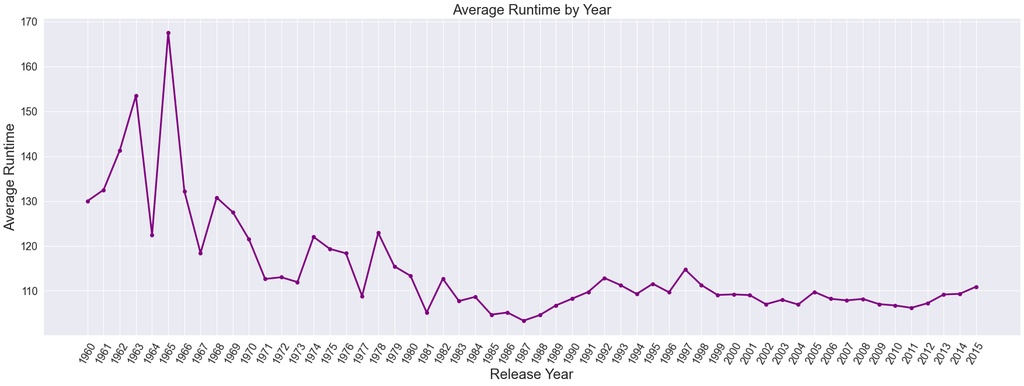

```python
plot_trend_over_years(av_runtime_by_yr, 'purple', 'Average Runtime by Year', 'Release Year', 'Average Runtime')
```

From the lineplot, the average runtime tend to decrease over the years

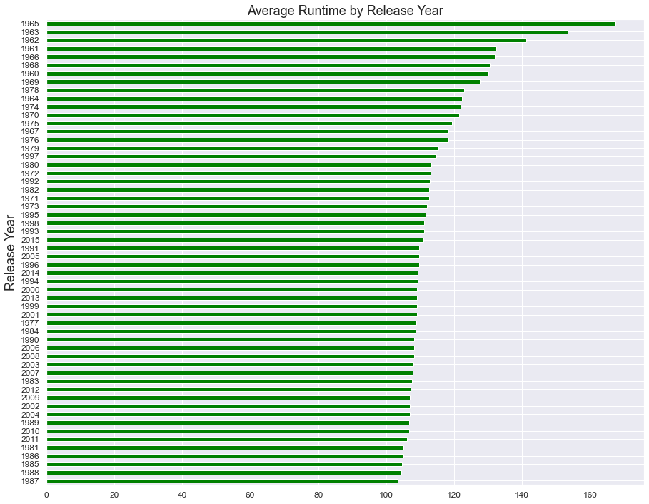

```python
av_runtime_by_yr.sort_values().plot(kind='barh', figsize=(15,12), color='green', fontsize=12, xlabel='Release Year', title='Average Runtime by Release Year')
```

From the bar plot above, the year in which the movies produced had the highest average runtime was 1965

# Who directed the most movies?

```python
# defining a function to create a bar plot

def plot_bar(data, xlabel, ylabel, title, color='skyblue', tick_fontsize=13, rotation=0):
    data.plot(kind='bar', color=color, figsize=(20,12), fontsize=tick_fontsize)
    plt.xticks(rotation=rotation)
    plt.xlabel(xlabel, fontdict={'fontsize':20})
    plt.ylabel(ylabel, fontdict={'fontsize':20})
    plt.title(title, fontdict={'fontsize':20})
    plt.show()
```

```python
movie_director_count = tmdb_data['director'].value_counts()
```

```python
movie_director_count
```

```
Steven Spielberg              27
Clint Eastwood                24
Ridley Scott                  21
Woody Allen                   18
Martin Scorsese               17
                              ..
Chris Weitz|Paul Weitz         1
Steve Beck                     1
Kelly Asbury|Lorna Cook        1
Larry Clark|Edward Lachman     1
Howard Hawks                   1
Name: director, Length: 1714, dtype: int64
```

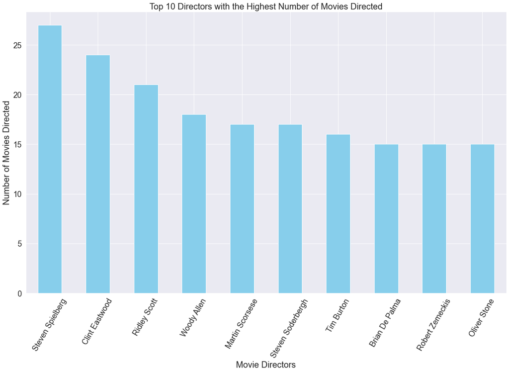

```python
plot_bar(movie_director_count[:10], 'Movie Directors', 'Number of Movies Directed', 'Top 10 Directors with the Highest Number of Movies Directed', tick_fontsize=18, rotation=60)
```

From the bar graph above, Steven Spielberg directed most movies followed by Clint Eastwood and Ridley Scott

# Which genres appears mostly?

```python
tmdb_data['genres']
```

```
0        Action|Adventure|Science Fiction|Thriller
1        Action|Adventure|Science Fiction|Thriller
2               Adventure|Science Fiction|Thriller
3         Action|Adventure|Science Fiction|Fantasy
4                            Action|Crime|Thriller
                           ...
10822                                        Drama
10828                             Mystery|Thriller
10829                               Action|Western
10835           Action|Adventure|Drama|War|Romance
10848                    Adventure|Science Fiction
Name: genres, Length: 3854, dtype: object
```

```python
tmdb_data['genres'] = tmdb_data['genres'].apply(lambda x: x.split('|'))
```

```python
tmdb_data['genres']
```

```
0        [Action, Adventure, Science Fiction, Thriller]
1        [Action, Adventure, Science Fiction, Thriller]
2                [Adventure, Science Fiction, Thriller]
3         [Action, Adventure, Science Fiction, Fantasy]
4                             [Action, Crime, Thriller]
                              ...
10822                                           [Drama]
10828                               [Mystery, Thriller]
10829                                 [Action, Western]
10835          [Action, Adventure, Drama, War, Romance]
10848                      [Adventure, Science Fiction]
Name: genres, Length: 3854, dtype: object
```

```python
from collections import defaultdict

genre_appearances = defaultdict(int)

for genre_list in tmdb_data['genres'].values:
    for genre in genre_list:
        genre_appearances[genre]+=1

sorted_genre_appearances = dict(sorted(genre_appearances.items(), key = lambda x: x[1], reverse=True))
```

```python
sorted_genre_appearances
```

```
{'Drama': 1756,
 'Comedy': 1358,
 'Thriller': 1204,
 'Action': 1085,
 'Adventure': 749,
 'Romance': 667,
 'Crime': 651,
 'Science Fiction': 519,
 'Horror': 463,
 'Family': 425,
 'Fantasy': 396,
 'Mystery': 344,
 'Animation': 201,
 'Music': 136,
 'History': 129,
 'War': 119,
 'Western': 52,
 'Documentary': 35,
 'Foreign': 13,
 'TV Movie': 1}
```

```python
# defining a function to create a bar plot from a dictionary

def plot_bar_from_dict(data, xlabel, ylabel, title, data_type='dict'):
    plt.figure(figsize=(25,10))
    if data_type == 'dict':
        plt.bar(x=data.keys(), height=data.values())
    elif data_type == 'list':
        plt.bar(x=list(data.keys())[:10], height=list(data.values())[:10])
    plt.xlabel(xlabel, fontdict={'fontsize': 20})
    plt.ylabel(ylabel, fontdict={'fontsize': 20})
    plt.title(title)
    plt.xticks(rotation=50, fontsize=20)
    plt.yticks(fontsize=18)
    plt.show()
```

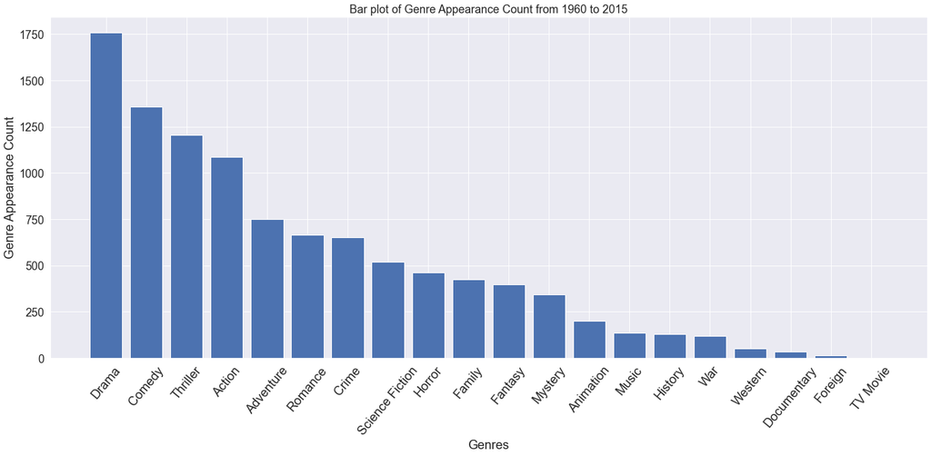

```python
plot_bar_from_dict(sorted_genre_appearances, 'Genres', 'Genre Appearance Count', 'Bar plot of Genre Appearance Count from 1960 to 2015')
```

From the plot above, we see that the Drama genre occured most frequently followed by the Comedy genre and the Thriller genre